# Zebrafish BaP study metagenomics preprocessing

Alexandra Alexiev

## Housekeeping/start up

Run this every session

```r
library(dplyr)
library(tidyr)
library(ggplot2)
library(knitr)
library(metaGTx.processing)
library(magrittr)
library(stringr)
set.seed(3)
home_dir <- "/nfs5/Sharpton_Lab/alexieva/metagen_zfBaP/"
catseq_dir <- "/nfs5/Sharpton_Lab/alexieva/metagen_zfBaP/catseq_zips/"
# setwd('/nfs5/Sharpton_Lab/alexieva/metagen_zfBaP/') keep commented out when
# not in use because fucks up knitting
```

## Save and load workspace

Always run at the beginning and end of each session

```r
# save.image('zfBaP_MGproc.RData')
load("zfBaP_MGproc.RData")
```

## Concatenate Sequence Files

Because each sample was sequenced on multiple lanes, I have to now concatenate them. I looked into whether concatenating is ok (which seems like it is standard based on many biology forums I checked), and checked that alpha diversity of genes and taxa were the same across lanes from the same sample and that each lane file for a sample had the same sequencing depth (all confirmed).

```bash
ssh -732 alexieva@shell.cqls.oregonstate.edu # and log in as usual
qrsh -q darwin@darwin # Sharpton lab compute server
cd nfs5/Sharpton_Lab/alexieva/metagen_zfBaP # this is my working directory
screen -S copyseqsalex # make screen in case pipe is broken for some reason
# copy all files from Tom's directory into mine so I can work with them
cp -r /home/micro/sharptot/nfs/prod/prod_restructure/projects/BaP_adult_zfish/metagenomes/raw /nfs5/Sharpton_Lab/alexieva/metagen_zfBaP
# check if all files were transferred
ls -1 /home/micro/sharptot/nfs/prod/prod_restructure/projects/BaP_adult_zfish/metagenomes/raw | wc -l
ls -1 /nfs5/Sharpton_Lab/alexieva/metagen_zfBaP/raw | wc -l
# all got transferred

# meanwhile, also move metadata file from my computer to server folder
scp -P 732 /Users/alal3493/Documents/Projects/zebrafishBaP/metadata/*.csv alexieva@files.cqls.oregonstate.edu:/nfs5/Sharpton_Lab/alexieva/metagen_zfBaP/metadata

# check if there are files for each sample ID present
nano seqfilecheck.txt # make empty text file for output
screen -S checkfilesalex
samplesList=$(<sample_list.txt) # string of all sample names to iterate through
cd raw/ # go to this directory
for i in ${samplesList[@]}; do echo $i ; find *$i*R1*.fastq.gz | wc -l ; done > /nfs5/Sharpton_Lab/alexieva/metagen_zfBaP/seqfilecheck.txt
# all sample files are present and accounted for
```

```r
# read in csv for full metadata file
metadata_all <- read.csv(paste0(home_dir, "metadata/zfBaP_metadata.csv"), header = T)  # 425 samples
# read in all the measurement data
metadata_fishMeasurements <- read.csv(paste0(home_dir, "metadata/zfBaP_ALLFishMeasurements.csv"),
    header = T)  # 425 samples

## join it all into one big file and remove repeated columns
metadata_allFishMrmnts <- metadata_all %>%
    inner_join(metadata_fishMeasurements, by = "SampleIDExtra") %>%
    select(-c("Treatments.y", "Generation.y", "Gender.y", "Morphology.y", "Exposure.y",
        "FishNumber.y", "Tissue.y", "RunID.y"))
# remove the .x at the end of some column headers
colnames(metadata_allFishMrmnts) <- gsub(".x$", "", colnames(metadata_allFishMrmnts))
# replace + in Treatments column with _
metadata_allFishMrmnts$Treatments <- gsub("\\+", "_", metadata_allFishMrmnts$Treatments)
# save it write.csv(metadata_allFishMrmnts, paste0(home_dir,
# 'metadata/zfBaP_ALL.csv'))
```

```r
# extract just the sample column for ease of reference in for loop
Samps <- metadata_allFishMrmnts$SampleID

# made an empty commands file using nano in terminal
cmds_catseq <- c()

for (i in 1:length(Samps)) {
    # for each sample
    samp_id <- Samps[i]
    cmd <- paste0("cd /nfs5/Sharpton_Lab/alexieva/metagen_zfBaP/raw ; zcat *", samp_id,
        "*R1*.fastq.gz > catseqs/", samp_id, "_R1.fastq ;")  # paste this line that uses the sample name
    cmds_catseq[i] <- cmd

}
head(cmds_catseq)  # check looks good
```

```
## [1] "cd /nfs5/Sharpton_Lab/alexieva/metagen_zfBaP/raw ; zcat *BaP_0867*R1*.fastq.gz > catseqs/BaP_0867_R1.fastq ;"
## [2] "cd /nfs5/Sharpton_Lab/alexieva/metagen_zfBaP/raw ; zcat *BaP_0868*R1*.fastq.gz > catseqs/BaP_0868_R1.fastq ;"
## [3] "cd /nfs5/Sharpton_Lab/alexieva/metagen_zfBaP/raw ; zcat *BaP_0869*R1*.fastq.gz > catseqs/BaP_0869_R1.fastq ;"
## [4] "cd /nfs5/Sharpton_Lab/alexieva/metagen_zfBaP/raw ; zcat *BaP_0870*R1*.fastq.gz > catseqs/BaP_0870_R1.fastq ;"
## [5] "cd /nfs5/Sharpton_Lab/alexieva/metagen_zfBaP/raw ; zcat *BaP_0871*R1*.fastq.gz > catseqs/BaP_0871_R1.fastq ;"
## [6] "cd /nfs5/Sharpton_Lab/alexieva/metagen_zfBaP/raw ; zcat *BaP_0872*R1*.fastq.gz > catseqs/BaP_0872_R1.fastq ;"
```

```r
length(cmds_catseq)  # check got to correct length
```

```
## [1] 425
```

```r
writeLines(cmds_catseq, con = file(paste0(home_dir, "Jobs/zcat_seqs.txt")))
close(file(paste0(home_dir, "Jobs/zcat_seqs.txt")))
# only doing for R1 forward reads because paired doesn't add any information
```

Put into SGE_Array script to run quickly

```bash
# SGE submission script that is run from Vaughan server
mkdir raw/catseqs
cd /nfs5/Sharpton_Lab/alexieva/metagen_zfBaP/SGE_outputs/
screen -S catseqsalexieva
SGE_Array -c /nfs5/Sharpton_Lab/alexieva/metagen_zfBaP/Jobs/zcat_seqs.txt -q darwin@darwin -P 10 -b 5 -f 50G
# c is the command file
# q is the server name
# P is processors
# b is for threads
# f is for memory

# job ID: 9940457
qstat # to check status of job
screen -d # to detach
screen -r # to reattach and check on process
# time start: Aug.15.2022 12:36:35
# time end: Aug.15.2022 15:56
# check folder to see if it worked, count number of files
cd /nfs5/Sharpton_Lab/alexieva/metagen_zfBaP/catseqs
ls -1 | wc -l
# this is the right number of files
# check they have something in them
ls -s
# all have information in them
```

# Check sequence distribution of files

We want to make sure the distribution of sequence depth is even across files. If not, we’ll have to rarefy. Also confirms if the humann normalization method will be appropriate.

```bash
nano rawseqttls.txt # make empty text file for output
screen -S seqcountsalexieva
cd catseqs
for f in *.fastq ; do echo ${f} ; grep -o -i ^@ ${f} | wc -l ; done > /nfs5/Sharpton_Lab/alexieva/metagen_zfBaP/rawseqttls.txt
```

```r
# need to read in seq counts from above chunk odd rows have sample IDs and even
# rows have seq count so need to separate into two columns
rawseq_ttls <- read.delim(paste0(home_dir, "rawseqttls.txt"), header = F, sep = "\t") %>%
    mutate(ind = rep(c(1, 2), length.out = n())) %>%
    group_by(ind) %>%
    mutate(id = row_number()) %>%
    spread(ind, V1) %>%
    select(-id) %>%
    mutate(ind = rep(1))  # add a column of 1 repeated for purpose of graphing x axis in plot
names(rawseq_ttls)[1] <- "SampleID"
names(rawseq_ttls)[2] <- "TotalSequenceCount"
rawseq_ttls$TotalSequenceCount <- as.numeric(rawseq_ttls$TotalSequenceCount)
```

```r
kable(rawseq_ttls[1:2])
```

| SampleID | TotalSequenceCount |
| --- | --- |
| BaP_0001_R1.fastq | 7644649 |
| BaP_0002_R1.fastq | 3782686 |
| BaP_0003_R1.fastq | 4003177 |
| BaP_0004_R1.fastq | 972182 |
| BaP_0005_R1.fastq | 3594572 |
| BaP_0006_R1.fastq | 2832429 |
| BaP_0007_R1.fastq | 2067246 |
| BaP_0008_R1.fastq | 2124363 |
| BaP_0009_R1.fastq | 704131 |
| BaP_0010_R1.fastq | 1704066 |
| BaP_0011_R1.fastq | 1941930 |
| BaP_0012_R1.fastq | 3731240 |
| BaP_0013_R1.fastq | 1275904 |
| BaP_0014_R1.fastq | 2533029 |
| BaP_0015_R1.fastq | 2320302 |
| BaP_0016_R1.fastq | 3430918 |
| BaP_0017_R1.fastq | 1042494 |
| BaP_0018_R1.fastq | 5617258 |
| BaP_0019_R1.fastq | 1675336 |
| BaP_0020_R1.fastq | 4695685 |
| BaP_0021_R1.fastq | 4199763 |
| BaP_0022_R1.fastq | 3631319 |
| BaP_0023_R1.fastq | 4918579 |
| BaP_0024_R1.fastq | 4185688 |
| BaP_0025_R1.fastq | 3783378 |
| BaP_0026_R1.fastq | 3312621 |
| BaP_0027_R1.fastq | 3015986 |
| BaP_0028_R1.fastq | 3079550 |
| BaP_0029_R1.fastq | 2723620 |
| BaP_0030_R1.fastq | 3071519 |

[output cut: 395 more lines]

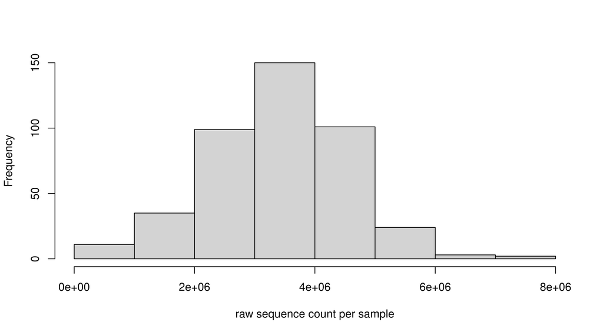

```r
hist(rawseq_ttls$TotalSequenceCount, xlab = "raw sequence count per sample", main = "")
```

```r
# boxplot with stats
min(rawseq_ttls$TotalSequenceCount)
```

```
## [1] 15230
```

```r
max(rawseq_ttls$TotalSequenceCount)
```

```
## [1] 7644649
```

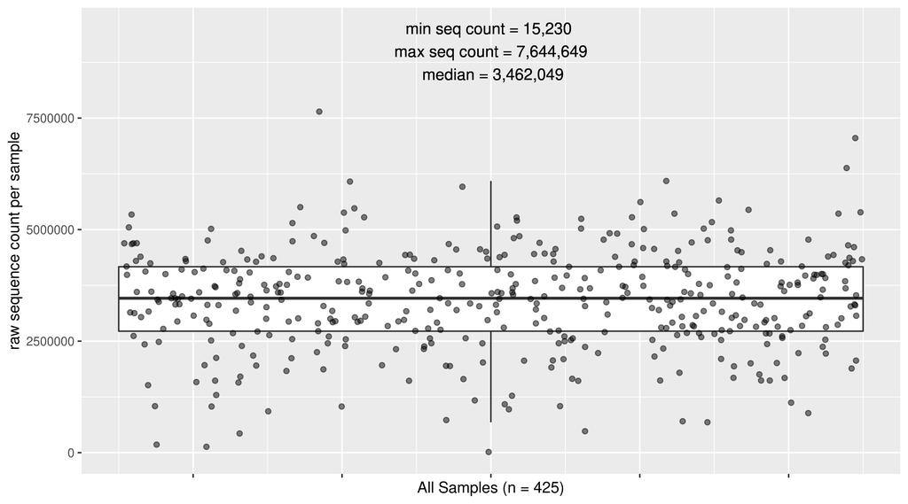

```r
seq_box <- ggplot(data = rawseq_ttls, aes(x = ind, y = TotalSequenceCount)) + geom_boxplot(outlier.shape = NA,
    width = 0.5) + geom_point(position = position_jitter(width = 0.25), alpha = 0.5) +
    xlab("All Samples (n = 425)") + ylab("raw sequence count per sample") + theme(axis.text.x = element_blank()) +
    ylim(c(0, 9500000)) + geom_text(x = 1, y = 9e+06, size = 4, label = "min seq count = 15,230 \n max seq count = 7,644,649 \n median = 3,462,049")  # the min and max of the whole dataset with median from table below
seq_box
```

```r
# ggsave(paste0(home_dir, 'figs/seqboxplot.tiff'), seq_box, dpi = 300, width =
# 7, height = 6)
seqbox_stats <- layer_data(seq_box)
kable(seqbox_stats[1:6], caption = "Stats from boxplot of sequence counts")
```

Stats from boxplot of sequence counts

| ymin | lower | middle | upper | ymax | outliers |
| --- | --- | --- | --- | --- | --- |
| 681995 | 2723620 | 3462049 | 4167662 | 6090348 | 7644649, 429841, 180715, 15230, 132370, 481318, 6380687, 7052163 |

```r
# ymin is the min excluding outliers lower is the 25th percentile value middle
# is the median upper is the 75th percentile value ymax is the max excluding
# outliers outliers are listed
```

Some samples are quite low in sequence count so want to make sure they’re not all from the same sample or something.

```r
seqcnt_metadata <- rawseq_ttls %>%
    select(-ind) %>%
    rename(SeqFileName = SampleID) %>%
    mutate(SampleID = substr(SeqFileName, 1, 8)) %>%
    full_join(metadata_all, by = "SampleID") %>%
    select(-SampleIDExtra)
kable(seqcnt_metadata)
```

| SeqFileName | TotalSequenceCount | SampleID | Treatments | Generation | Gender | Morphology | Exposure | FishNumber | Tissue | RunID |
| --- | --- | --- | --- | --- | --- | --- | --- | --- | --- | --- |
| BaP_0001_R1.fastq | 7644649 | BaP_0001 | AHR2Mo+BaP | F2 | F | AHR2Mo | BaP | 141 | Fecal | s434 |
| BaP_0002_R1.fastq | 3782686 | BaP_0002 | AHR2Mo+BaP | F2 | F | AHR2Mo | BaP | 135 | Fecal | s428 |
| BaP_0003_R1.fastq | 4003177 | BaP_0003 | AHR2Mo+DMSO | F0 | F | AHR2Mo | DMSO | 93 | Fecal | s097 |
| BaP_0004_R1.fastq | 972182 | BaP_0004 | AHR2Mo+DMSO | F0 | F | AHR2Mo | DMSO | 94 | Fecal | s098 |
| BaP_0005_R1.fastq | 3594572 | BaP_0005 | AHR2Mo+DMSO | F0 | F | AHR2Mo | DMSO | 95 | Fecal | s099 |
| BaP_0006_R1.fastq | 2832429 | BaP_0006 | AHR2Mo+DMSO | F0 | M | AHR2Mo | DMSO | 96 | Fecal | s100 |
| BaP_0007_R1.fastq | 2067246 | BaP_0007 | AHR2Mo+DMSO | F0 | F | AHR2Mo | DMSO | 97 | Fecal | s101 |
| BaP_0008_R1.fastq | 2124363 | BaP_0008 | AHR2Mo+DMSO | F0 | M | AHR2Mo | DMSO | 98 | Fecal | s102 |
| BaP_0009_R1.fastq | 704131 | BaP_0009 | CoMo+DMSO | F1 | F | CoMo | DMSO | 9 | Fecal | s157 |
| BaP_0010_R1.fastq | 1704066 | BaP_0010 | CoMo+DMSO | F1 | M | CoMo | DMSO | 10 | Fecal | s158 |
| BaP_0011_R1.fastq | 1941930 | BaP_0011 | CoMo+DMSO | F1 | F | CoMo | DMSO | 11 | Fecal | s159 |
| BaP_0012_R1.fastq | 3731240 | BaP_0012 | CoMo+DMSO | F1 | M | CoMo | DMSO | 12 | Fecal | s160 |
| BaP_0013_R1.fastq | 1275904 | BaP_0013 | CoMo+DMSO | F1 | F | CoMo | DMSO | 13 | Fecal | s161 |
| BaP_0014_R1.fastq | 2533029 | BaP_0014 | CoMo+DMSO | F1 | M | CoMo | DMSO | 14 | Fecal | s162 |
| BaP_0015_R1.fastq | 2320302 | BaP_0015 | CoMo+DMSO | F1 | F | CoMo | DMSO | 15 | Fecal | s163 |
| BaP_0016_R1.fastq | 3430918 | BaP_0016 | CoMo+DMSO | F1 | M | CoMo | DMSO | 16 | Fecal | s164 |
| BaP_0017_R1.fastq | 1042494 | BaP_0017 | CoMo+BaP | F1 | F | CoMo | BaP | 71 | Fecal | s221 |
| BaP_0018_R1.fastq | 5617258 | BaP_0018 | CoMo+BaP | F1 | M | CoMo | BaP | 72 | Fecal | s222 |
| BaP_0019_R1.fastq | 1675336 | BaP_0019 | AHR2Mo+DMSO | F1 | F | AHR2Mo | DMSO | 73 | Fecal | s223 |
| BaP_0020_R1.fastq | 4695685 | BaP_0020 | AHR2Mo+DMSO | F1 | M | AHR2Mo | DMSO | 74 | Fecal | s224 |
| BaP_0021_R1.fastq | 4199763 | BaP_0021 | AHR2Mo+DMSO | F1 | F | AHR2Mo | DMSO | 75 | Fecal | s225 |
| BaP_0022_R1.fastq | 3631319 | BaP_0022 | AHR2Mo+DMSO | F1 | M | AHR2Mo | DMSO | 76 | Fecal | s226 |
| BaP_0023_R1.fastq | 4918579 | BaP_0023 | AHR2Mo+DMSO | F1 | F | AHR2Mo | DMSO | 77 | Fecal | s227 |
| BaP_0024_R1.fastq | 4185688 | BaP_0024 | AHR2Mo+DMSO | F1 | M | AHR2Mo | DMSO | 78 | Fecal | s228 |
| BaP_0025_R1.fastq | 3783378 | BaP_0025 | CoMo+DMSO | F2 | F | CoMo | DMSO | 5 | Fecal | s299 |
| BaP_0026_R1.fastq | 3312621 | BaP_0026 | CoMo+DMSO | F2 | M | CoMo | DMSO | 6 | Fecal | s300 |
| BaP_0027_R1.fastq | 3015986 | BaP_0027 | CoMo+DMSO | F2 | F | CoMo | DMSO | 7 | Fecal | s301 |
| BaP_0028_R1.fastq | 3079550 | BaP_0028 | CoMo+DMSO | F2 | M | CoMo | DMSO | 8 | Fecal | s302 |
| BaP_0029_R1.fastq | 2723620 | BaP_0029 | CoMo+DMSO | F2 | F | CoMo | DMSO | 9 | Fecal | s303 |
| BaP_0030_R1.fastq | 3071519 | BaP_0030 | CoMo+DMSO | F2 | M | CoMo | DMSO | 10 | Fecal | s304 |

[output cut: 395 more lines]

```r
# write.table(seqcnt_metadata, file = paste0(home_dir,
# 'figs/seqcnt_metadata.txt'), sep = '\t')

# only the ones that are outliers
outlier_seqs <- unlist(seqbox_stats$outliers)
outlier_metadata <- filter(seqcnt_metadata, TotalSequenceCount %in% outlier_seqs)
kable(outlier_metadata)
```

| SeqFileName | TotalSequenceCount | SampleID | Treatments | Generation | Gender | Morphology | Exposure | FishNumber | Tissue | RunID |
| --- | --- | --- | --- | --- | --- | --- | --- | --- | --- | --- |
| BaP_0001_R1.fastq | 7644649 | BaP_0001 | AHR2Mo+BaP | F2 | F | AHR2Mo | BaP | 141 | Fecal | s434 |
| BaP_0040_R1.fastq | 429841 | BaP_0040 | AHR2Mo+DMSO | F0 | F | AHR2Mo | DMSO | 102 | Fecal | s106 |
| BaP_0082_R1.fastq | 180715 | BaP_0082 | CoMo+DMSO | F1 | M | CoMo | DMSO | 26 | Fecal | s174 |
| BaP_0120_R1.fastq | 15230 | BaP_0120 | CoMo+DMSO | F1 | M | CoMo | DMSO | 36 | Fecal | s184 |
| BaP_0449_R1.fastq | 132370 | BaP_0449 | AHR2Mo+DMSO | F1 | F | AHR2Mo | DMSO | 101 | Fecal | s251 |
| BaP_0971_R1.fastq | 481318 | BaP_0971 | AHR2Mo+BaP | F2 | F | AHR2Mo | BaP | 121 | Fecal | s411 |
| BaP_1103_R1.fastq | 6380687 | BaP_1103 | AHR2Mo+DMSO | F0 | M | AHR2Mo | DMSO | 91 | Fecal | s093 |
| BaP_1104_R1.fastq | 7052163 | BaP_1104 | AHR2Mo+DMSO | F0 | M | AHR2Mo | DMSO | 92 | Fecal | s094 |

```r
# write.table(outlier_metadata, file = paste0(home_dir,
# 'figs/outlier_metadata.txt'), sep = '\t')
```

## Begin Processing Metagenomic Files

# Before I start, I have to rezip the fastq files for this workflow to work

```bash
# copy folder of concatenated seq files into new file
mkdir catseq_zips
cp catseqs/* catseq_zips
ls -1 catseq_zips | wc -l
# zip them all up
gzip catseq_zips/*
```

# Now create environment and do other set up steps

```r
# create processing environment to make output commands and files
# create.processing.env( interactive = FALSE, job.queue = 'darwin@darwin',
# jobs.dir = '/nfs5/Sharpton_Lab/alexieva/metagen_zfBaP/Jobs', max.cores = 200,
# max.concurrent.jobs = 4, base.dir =
# '/nfs5/Sharpton_Lab/alexieva/metagen_zfBaP', raw.seq.dirs =
# '/nfs5/Sharpton_Lab/alexieva/metagen_zfBaP/catseq_zips', store.dir =
# '/nfs5/Sharpton_Lab/alexieva/metagen_zfBaP/outputs', link.dir =
# file.path(base.dir, 'WorkingFiles'), temp.dir = file.path(base.dir,
# 'Results'), # optional, a directory for writing immediate output that will
# then get, e.g. zipped and moved to the store.dir max.memory = '100G',
# knead.host.db =
# '/nfs5/Sharpton_Lab/alexieva/public_databases/zebrafishGRCz11_genome_jul182022/zebrafish_db',
# samples = print(Samps), save.env.dir = 'Run_envs' # for saving this
# processing environment for future use or to share with others.  )

# can use existing environment file after running above lines once
load("Run_envs/metaGTx_processing_environment_2022-08-18_13-00-21.RData")

# set some objects to hold this information
concurrent.jobs <- ifelse(run.env$interactive, 1, run.env$max.concurrent.jobs)
cores.per.job <- floor(run.env$max.cores/concurrent.jobs)

# set up folder system (only if they don't already exist)
for (dir in c(run.env$link.dir, run.env$temp.dir, run.env$store.dir)) {
    if (!dir.exists(dir)) {
        dir.create(dir)
    }
}
```

```bash
# move some of these sequence files elsewhere
mkdir RAWseqs
mv raw/ RAWseqs
mv catseqs/ RAWseqs
mv *.txt RAWseqs
```

# Step 1: kneaddata on files

KneadData (from the Huttenhower lab) does quality control on the data. It removes contaminant reads that match the host (via Bowtie2). It also trims to sequences with Trimmomatic. More here: https://github.com/biobakery/kneaddata#paired-end-run

```r
# set symlinks so original files don't get messed up
setwd(run.env$link.dir)
symlink.raw.fastqs(
  fastq.dirs = run.env$raw.seq.dirs,
  pattern = ".*fastq\\.gz",
  delim = "_R1", # get this from raw fastq file names
  sample.field = 1 # get this from raw fastq file names
)
setwd(run.env$base.dir)

# make output directories if they don't already exist
knead.output <- file.path(run.env$store.dir, "KneadData_output") # path to store QC'd sequences
knead.other <- file.path(run.env$store.dir, "KneadData_other") # path for other kneaddata output files
knead.array.file <- file.path(run.env$jobs.dir, "kneaddata_array_commands.txt")
for (dir in c(knead.output, knead.other)) {
  if (!dir.exists(dir)) { dir.create(dir) }
}
```

```r
commands <- generate.full.commands(tool = "kneaddata", paired = FALSE, input.dir = run.env$link.dir,
    output.dir = run.env$store.dir, tmp.dir = run.env$temp.dir, reference.db = run.env$knead.host.db,
    threads = cores.per.job, zip.output = TRUE, write.to = knead.array.file)
head(commands)  # inspect commands for accuracy
if (run.env$interactive) {
    execute.commands(commands)
} else {
    generate.SGE.command(c = knead.array.file, q = run.env$job.queue, P = cores.per.job,
        b = concurrent.jobs, f = run.env$max.memory, qsub_options = run.env$qsub.options)
    # Submit job with printed command from appropriate machine
}
```

```bash
# log into Vaughan server
screen -S kneaddataalexieva
cd /nfs5/Sharpton_Lab/alexieva/metagen_zfBaP/SGE_outputs

SGE_Array -c /nfs5/Sharpton_Lab/alexieva/metagen_zfBaP/Jobs/kneaddata_array_commands.txt -q darwin@darwin -P 50 -b 4 -f 100G
# job ID: 9943489
qstat # to check status of job
screen -d # to detach
screen -r # to reattach and check on process
# time start: Aug.18.2022 13:06
# time end: Aug.22.2022 1:41
```

```r
# move files with file name BaP_###--R1_kneaddata.fastq
move.files(move.from = run.env$store.dir, move.to = knead.output, match.pattern = "kneaddata.fastq.gz")
# move the rest of the intermediate files from kneaddata
move.files(move.from = run.env$store.dir, move.to = knead.other, match.pattern = "\\.gz$")
```

```bash
cd outputs/KneadData_output/

# check 425 files exist
ls -1 | wc -l
# all there

# check they have file sizes that make sense (no empties)
ls -s
# all files have data in them
```

# Step 2: Run Humann on files

Humann profiles the presence/absence and abundance of microbial gene pathways from metagenomic sequence data. See more here: https://github.com/biobakery/humann#how-to-run

```r
# set new symlinks in working files folder
setwd(run.env$link.dir)
file.remove(list.files())
symlink.files(file.dir = knead.output, pattern = "kneaddata.fastq.gz")
setwd(run.env$base.dir)

# create new directories for outputs
humann.output <- file.path(run.env$store.dir, "Humann_output")
humann.array.file <- file.path(run.env$jobs.dir, "humann_array_commands.txt")

if (!dir.exists(humann.output)) {
    dir.create(humann.output)
}
```

```r
commands <- generate.full.commands(tool = "humann", paired = FALSE, input.dir = run.env$link.dir,
    output.dir = humann.output, tmp.dir = run.env$temp.dir, threads = cores.per.job,
    write.to = humann.array.file)
# above code gives error 'can only write character objects tried defining all
# arguments explicitly, checked all arguments are correct ran the source code
# for the function and got a commands file, so going to use that in the absence
# of a better solution
head(commands)  # inspect commands for accuracy
if (run.env$interactive) {
    execute.commands(commands)
} else {
    generate.SGE.command(c = humann.array.file, q = run.env$job.queue, P = cores.per.job,
        b = concurrent.jobs, f = run.env$max.memory)
    ## Submit job with printed command from appropriate machine
}
```

```bash
# log into Vaughan server
screen -S humannalexieva
cd /nfs5/Sharpton_Lab/alexieva/metagen_zfBaP/SGE_outputs

# have to reconfigure the databases before starting
humann_config --update database_folders nucleotide /nfs3/Sharpton_Lab/public_databases/chocophlan
humann_config # check

SGE_Array -c /nfs5/Sharpton_Lab/alexieva/metagen_zfBaP/Jobs/humann_array_commands.txt -q darwin@papilio -P 200 -b 4 -f 100G
# job ID: 9946562
qstat # to check status of job
screen -d # to detach
screen -r 10568.humannalexieva # to reattach and check on process
# time start: Aug.23.2022 16:03:44
##THIS IS TAKING TOO LONG, MOVING TO DIFFERENT SERVER
# time killed job:
# qdel 9946562 to stop process
```